# Final Project

Marisa Manno, Georgia Wright, Elizabeth Chin

12/1/2021

```r
atus <- read.delim("atusact-0320/atusact_0320.dat", sep="," , header=T)
atus <- atus %>%
  format(atus$TUCASEID, scientific = FALSE)

roster <- read.delim("atusrost-0320/atusrost_0320.dat", sep="," , header=T)
roster<- roster %>%format(roster$TUCASEID, scientific = FALSE)
```

#### Variables:

We will be looking at how time spent on different categories of travel affects sleep, so we have listed the 6 digit (TRCODEP) code for sleep along with the 4 digit (TRTIER2P) codes of each category of travel, each starting with 18 to indicate traveling for that reason.

- 010101 sleeping
- 18 travel:
  - 1801 personal care
  - 1802 household activities
  - 1803 travel related to caring for household members
  - 1804 travel related to caring for nonhousehold members
  - 1805 work
  - 1806 education
  - 1807 consumer purchases
  - 1808 using professional and personal care services
  - 1809 household services
  - 1810 using government services and civic obligations
  - 1811 eating and drinking
  - 1812 socializing relaxing leisure
  - 1813 sports exercise recreation
  - 1814 religious/spiritual
  - 1815 volunteer
  - 1816 phone calls
  - 1818 security procedures related to traveling
  - 1899 nec

First, we filter our variables of interest from the atus data and select columns we need (i.e we did not include things like if a child was with you and where you were during the activity). We have called this shortened data frame “atus_main”

```r
atus_main <- atus %>%
  filter(TRCODEP == 010101 | TRTIER1P == 18 | TRTIER2P == 0201 | TRTIER2P == 0501 |
          TRTIER2P == 0601 | TRTIER2P == 1203 ) %>%
  dplyr::select(TUCASEID, TRCODEP, TRTIER1P, TRTIER2P, TUACTDUR)
```

#### Visualize each category of travel

atus_travel is our main data set with only the codes corresponding to travel. First is a bar graph of each category of travel show in hours of time spent on that category.

```r
atus_travel = atus_main %>%
  filter(TRTIER1P == 18 )

head(atus_travel)
```

```
##          TUCASEID TRCODEP TRTIER1P TRTIER2P TUACTDUR
## 14 20030100013344  181201       18     1812       10
## 16 20030100013344  181201       18     1812       10
## 23 20030100013352  180701       18     1807        5
## 25 20030100013352  180701       18     1807        5
## 54 20030100014165  180501       18     1805       15
## 56 20030100014165  180802       18     1808        3
```

We are going to determine how many hours were spent for each travel related activity across households. We predict that the most time spent traveling will be related to work, education, and caring for household members.

```r
travel_sum <- atus_travel %>%
  group_by(TRTIER2P) %>%
  summarise(min=sum(as.numeric(TUACTDUR)))  %>%
  mutate(hours=min/60)


head(travel_sum)
```

```
## # A tibble: 6 × 3
##   TRTIER2P     min  hours
##   <I<chr>>   <dbl>  <dbl>
## 1 1801      209137  3486.
## 2 1802      599730  9996.
## 3 1803     1085844 18097.
## 4 1804      853092 14218.
## 5 1805     2797963 46633.
## 6 1806      212611  3544.
```

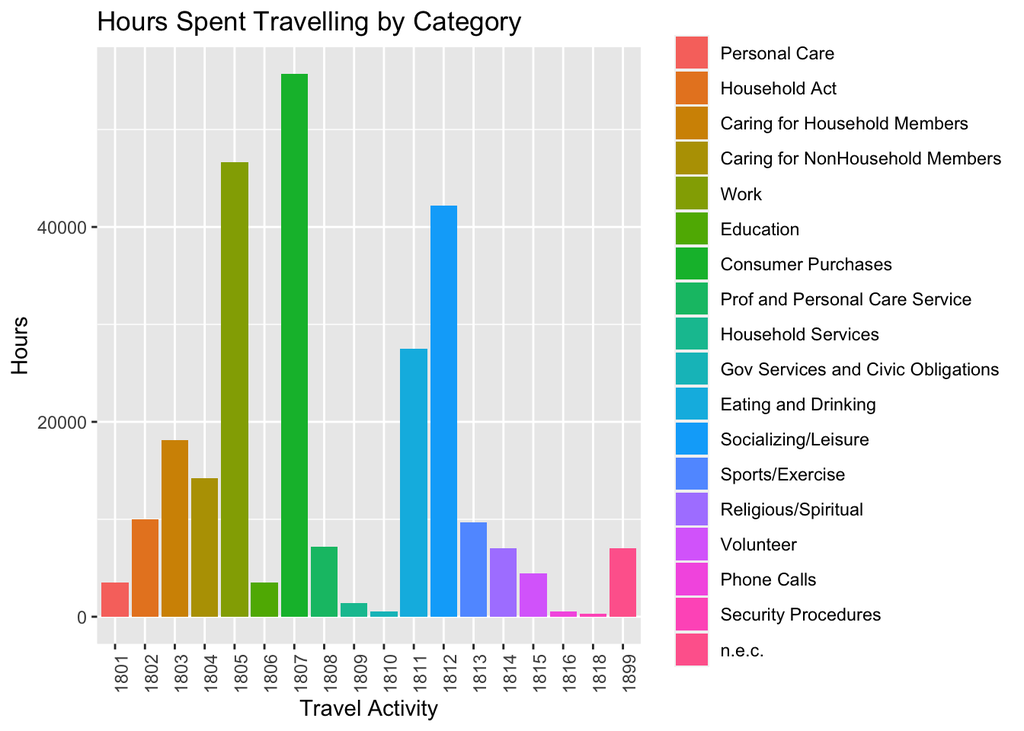

```r
travel_sum$TRTIER2P <- as.factor(travel_sum$TRTIER2P)

colorCount = nrow(travel_sum)
getPalette = colorRampPalette(brewer.pal(9, "Set1"))

ggplot(travel_sum, aes(x=TRTIER2P, y=hours, fill=TRTIER2P)) +
geom_bar(stat = "identity")  +
  theme(axis.text.x=element_text(angle = 90, hjust = 0)) +
  ggtitle("Hours Spent Travelling by Category") +
  xlab("Travel Activity") +
  ylab("Hours") +
  scale_fill_hue(name = NULL, labels = c("Personal Care", "Household Act", "Caring for Household Members",
                         "Caring for NonHousehold Members", "Work", "Education",
                         "Consumer Purchases", "Prof and Personal Care Service",
                         "Household Services", "Gov Services and Civic Obligations",
                         "Eating and Drinking", "Socializing/Leisure", "Sports/Exercise",
                         "Religious/Spiritual", "Volunteer", "Phone Calls",
                         "Security Procedures", "n.e.c."))
```

This bar chart is a visualization of total hours spent for each travel activity across all households. Overall, the most time spent traveling is for consumer purchases. The second most is time spent traveling is for work followed by socializing and leisure.

#### Use the ATUS Roster file to visualize travel activities based on sex and age (18 and older)

```r
roster$TEAGE <- as.numeric(roster$TEAGE)
roster1<- roster %>% filter(TEAGE>=18)
rost_act<- roster1 %>% left_join(atus_main, by="TUCASEID")
```

Create variables for age_group and sex:

```r
rost_act1<-rost_act %>% mutate(age_group = ifelse(TEAGE <=25, "18-25",
                                 ifelse(TEAGE<=35, "26-35",
                                 ifelse(TEAGE<=45, "36-45",
                                 ifelse(TEAGE<=55, "46-55",
                                ifelse(TEAGE<=65, "56-65",
                                ifelse(TEAGE<=75, "66-75",
                                ifelse(TEAGE<=85, "76-85",))))))))
head(rost_act1)
```

```
##         TUCASEID TULINENO TERRP TEAGE TESEX TRCODEP TRTIER1P TRTIER2P TUACTDUR
## 1 20030100013280        1    18    60     1   10101        1      101      600
## 2 20030100013280        1    18    60     1  120303       12     1203      150
## 3 20030100013280        1    18    60     1  120303       12     1203      175
## 4 20030100013280        1    18    60     1   10101        1      101      270
## 5 20030100013280        2    20    72     2   10101        1      101      600
## 6 20030100013280        2    20    72     2  120303       12     1203      150
##   age_group
## 1     56-65
## 2     56-65
## 3     56-65
## 4     56-65
## 5     66-75
## 6     66-75
```

```r
rost_act2<- rost_act1 %>% mutate(sex= ifelse(TESEX=="2", "Female", "Male"))
head(rost_act2)
```

```
##         TUCASEID TULINENO TERRP TEAGE TESEX TRCODEP TRTIER1P TRTIER2P TUACTDUR
## 1 20030100013280        1    18    60     1   10101        1      101      600
## 2 20030100013280        1    18    60     1  120303       12     1203      150
## 3 20030100013280        1    18    60     1  120303       12     1203      175
## 4 20030100013280        1    18    60     1   10101        1      101      270
## 5 20030100013280        2    20    72     2   10101        1      101      600
## 6 20030100013280        2    20    72     2  120303       12     1203      150
##   age_group    sex
## 1     56-65   Male
## 2     56-65   Male
## 3     56-65   Male
## 4     56-65   Male
## 5     66-75 Female
## 6     66-75 Female
```

Filter to display only travel activities and select Case ID, Activity, Activity duration, Age Group, and Sex.

```r
travel2<- rost_act2 %>%
  filter(TRTIER1P == 18) %>%
  group_by(TUCASEID) %>%
  dplyr::select(TUCASEID, TRTIER1P, TRTIER2P, TUACTDUR, age_group, sex)
head(travel2)
```

```
## # A tibble: 6 × 6
## # Groups:   TUCASEID [2]
##   TUCASEID       TRTIER1P TRTIER2P TUACTDUR age_group sex
##   <I<chr>>       <I<chr>> <I<chr>> <I<chr>> <chr>     <chr>
## 1 20030100013344 18       1812     10       36-45     Female
## 2 20030100013344 18       1812     10       36-45     Female
## 3 20030100013344 18       1812     10       36-45     Male
## 4 20030100013344 18       1812     10       36-45     Male
## 5 20030100013352 18       1807     5        26-35     Female
## 6 20030100013352 18       1807     5        26-35     Female
```

Calculate hours spent traveling for each age group. We hypothesize that 36-45 year olds will spend the most time traveling because of work and childcare responsibilities.

```r
travel_age<-travel2 %>%
  group_by(age_group) %>%
  summarise(sum=sum(as.numeric(TUACTDUR))) %>%
  mutate(hours=sum/60)

travel_age
```

```
## # A tibble: 7 × 3
##   age_group     sum   hours
##   <chr>       <dbl>   <dbl>
## 1 18-25     3619260  60321
## 2 26-35     5415625  90260.
## 3 36-45     7065991 117767.
## 4 46-55     6237007 103950.
## 5 56-65     4139428  68990.
## 6 66-75     2368131  39469.
## 7 76-85     1256386  20940.
```

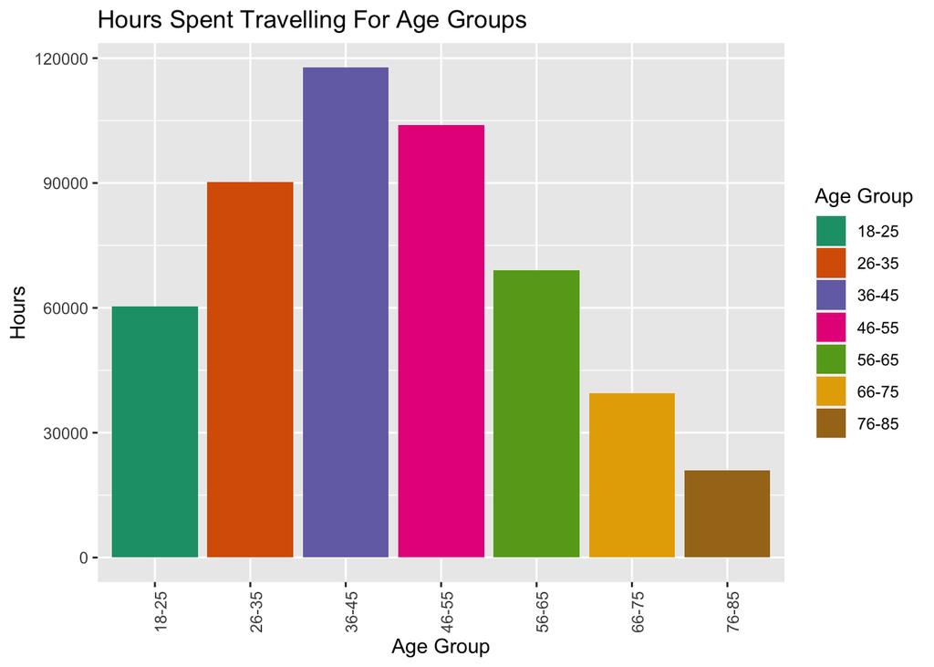

```r
ggplot(travel_age, aes(x=age_group, y=hours, fill=age_group))+
  geom_bar(stat = "identity")  +
  theme(axis.text.x=element_text(angle = 90, hjust = 0)) +
  ggtitle("Hours Spent Travelling For Age Groups") +
  xlab("Age Group") + ylab("Hours") +
  scale_fill_discrete(name = "Age Group") +
  scale_fill_brewer(palette = "Dark2") +
  guides(fill=guide_legend(title= "Age Group"))
```

The age-group 36-45 spends the most time traveling.

##### Travel activities of 36-45 year olds

```r
group3<-travel2 %>%
  filter(age_group=="36-45") %>%
  group_by(TRTIER2P) %>%
  summarise(sum=sum(as.numeric(TUACTDUR))) %>%
  mutate(hours=sum/60)

head(group3)
```

```
## # A tibble: 6 × 3
##   TRTIER2P     sum  hours
##   <I<chr>>   <dbl>  <dbl>
## 1 1801       84270  1404.
## 2 1802      241386  4023.
## 3 1803      818194 13637.
## 4 1804      301423  5024.
## 5 1805     1428195 23803.
## 6 1806      112942  1882.
```

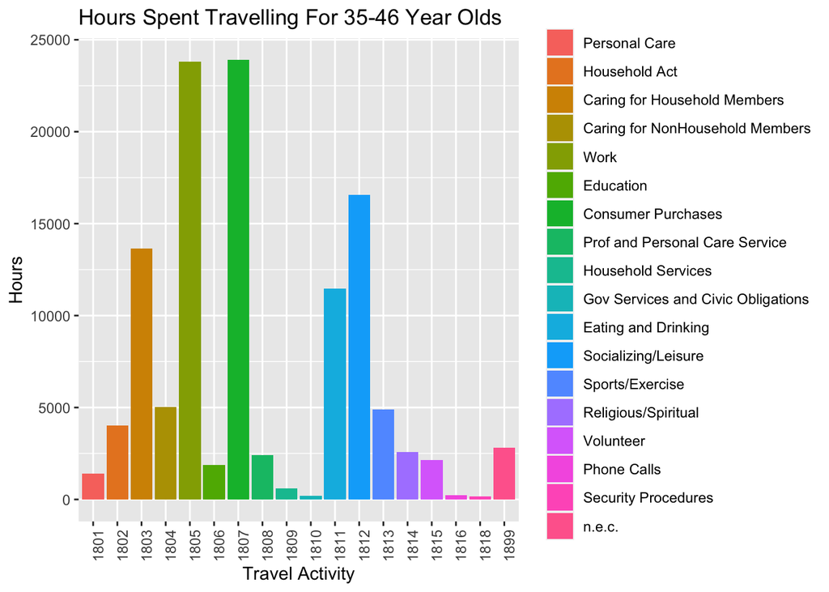

```r
group3$TRTIER2P <- as.factor(group3$TRTIER2P)

ggplot(group3, aes(x=TRTIER2P, y=hours, fill=TRTIER2P)) +
  geom_bar(stat = "identity")  +
  theme(axis.text.x=element_text(angle = 90, hjust = 0)) +
  ggtitle("Hours Spent Travelling For 35-46 Year Olds") +
  xlab("Travel Activity") + ylab("Hours") +
  scale_fill_hue(name = NULL, labels = c("Personal Care", "Household Act", "Caring for Household Members",
                         "Caring for NonHousehold Members", "Work", "Education",
                         "Consumer Purchases", "Prof and Personal Care Service",
                         "Household Services", "Gov Services and Civic Obligations",
                         "Eating and Drinking", "Socializing/Leisure", "Sports/Exercise",
                         "Religious/Spiritual", "Volunteer", "Phone Calls",
                         "Security Procedures", "n.e.c."))
```

##### Visualize time spent traveling for Females and Males

We are looking to determine if differences in time traveling activities exist based on sex.

```r
travel3<- travel2 %>%
  group_by(TRTIER2P, sex) %>%
  summarise(sum=sum(as.numeric(TUACTDUR))) %>%
  mutate(hours=sum/60)
travel3
```

```
## # A tibble: 36 × 4
## # Groups:   TRTIER2P [18]
##    TRTIER2P sex        sum  hours
##    <I<chr>> <chr>    <dbl>  <dbl>
##  1 1801     Female  208386  3473.
##  2 1801     Male    193420  3224.
##  3 1802     Female  598615  9977.
##  4 1802     Male    529942  8832.
##  5 1803     Female 1211208 20187.
##  6 1803     Male   1012558 16876.
##  7 1804     Female  822756 13713.
##  8 1804     Male    739209 12320.
##  9 1805     Female 2806897 46782.
## 10 1805     Male   2734155 45569.
## # … with 26 more rows
```

```r
travel4<- travel2 %>%
  group_by(sex) %>%
  summarise(sum=sum(as.numeric(TUACTDUR))) %>%
  mutate(hours=sum/60)
travel4
```

```
## # A tibble: 2 × 3
##   sex         sum   hours
##   <chr>     <dbl>   <dbl>
## 1 Female 15774924 262915.
## 2 Male   14326904 238782.
```

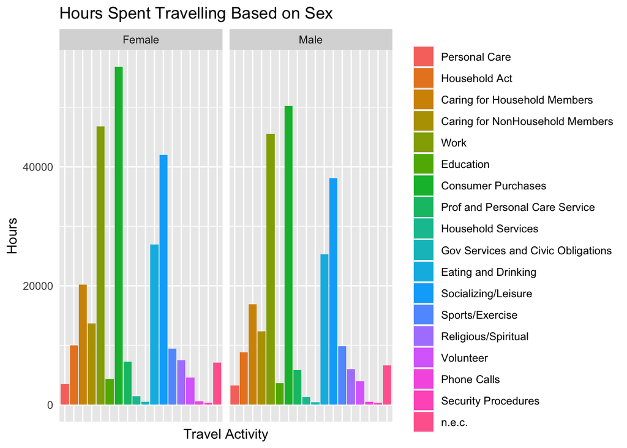

```r
travel3$TRTIER2P <- as.factor(travel3$TRTIER2P)

ggplot(travel3, aes(x=TRTIER2P, y=hours, fill=TRTIER2P)) +
  geom_bar(stat = "identity")  +
  theme(axis.text.x=element_text(angle = 90, hjust = 0)) +
  ggtitle("Hours Spent Travelling Based on Sex") +
  xlab("Travel Activity") + ylab("Hours") +
  facet_wrap("sex") +
  scale_fill_hue(name = NULL, labels = c("Personal Care", "Household Act", "Caring for Household Members",
                         "Caring for NonHousehold Members", "Work", "Education",
                         "Consumer Purchases", "Prof and Personal Care Service",
                         "Household Services", "Gov Services and Civic Obligations",
                         "Eating and Drinking", "Socializing/Leisure", "Sports/Exercise",
                         "Religious/Spiritual", "Volunteer", "Phone Calls",
                         "Security Procedures", "n.e.c.")) +
  theme(axis.ticks = element_blank(),
        axis.text.x = element_blank())
```

Overall, females spend more time traveling than males. Females spend more time than males for every travel activity besides travel related to sports, exercise, and recreation.

#### Scatter plot and linear model of Travel Categories on Sleep

First, we made data frames of each of the three travel categories we are interested in, along with one for sleep.

1807 Consumer Purchases

```r
atus_1807 <- atus_travel %>%
  group_by(TUCASEID) %>%
  filter(TRTIER2P == 1807) %>%
  summarise(sum_1807=sum(as.numeric(TUACTDUR)))

head(atus_1807)
```

```
## # A tibble: 6 × 2
##   TUCASEID       sum_1807
##   <I<chr>>          <dbl>
## 1 20030100013352       10
## 2 20030100014209       20
## 3 20030100014550       20
## 4 20030100014758       30
## 5 20030100015106        5
## 6 20030100015322       10
```

1805 Work

```r
atus_1805 <- atus_travel %>%
  group_by(TUCASEID) %>%
  filter(TRTIER2P == 1805) %>%
  summarise(sum_1805 =sum(as.numeric(TUACTDUR)))

head(atus_1805)
```

```
## # A tibble: 6 × 2
##   TUCASEID       sum_1805
##   <I<chr>>          <dbl>
## 1 20030100014165       15
## 2 20030100014427       50
## 3 20030100014758        4
## 4 20030100014928       59
## 5 20030100015322        3
## 6 20030100015490       75
```

1812 Socializing, Relaxing, Leisure

```r
atus_1812 <- atus_travel %>%
  group_by(TUCASEID) %>%
  filter(TRTIER2P == 1812) %>%
  summarise(sum_1812=sum(as.numeric(TUACTDUR)))

head(atus_1812)
```

```
## # A tibble: 6 × 2
##   TUCASEID       sum_1812
##   <I<chr>>          <dbl>
## 1 20030100013344       20
## 2 20030100014427       10
## 3 20030100014758       35
## 4 20030100015986       35
## 5 20030100016070       30
## 6 20030101030124        6
```

Sleep

```r
atus_sleep = atus_main %>%
  filter(TRCODEP == 010101) %>%
  group_by(TUCASEID) %>%
  dplyr::select(TUCASEID, TUACTDUR) %>%
  summarise(sum_sleep=sum(as.numeric(TUACTDUR)))

head(atus_sleep)
```

```
## # A tibble: 6 × 2
##   TUCASEID       sum_sleep
##   <I<chr>>           <dbl>
## 1 20030100013280       870
## 2 20030100013344       800
## 3 20030100013352       905
## 4 20030100013848       885
## 5 20030100014165       445
## 6 20030100014169       932
```

Plot of Consumer Purchases on Sleep (1807)

```r
reg_1807 <- left_join(atus_1807, atus_sleep, by = "TUCASEID")
head(reg_1807)
```

```
## # A tibble: 6 × 3
##   TUCASEID       sum_1807 sum_sleep
##   <I<chr>>          <dbl>     <dbl>
## 1 20030100013352       10       905
## 2 20030100014209       20       672
## 3 20030100014550       20       825
## 4 20030100014758       30       180
## 5 20030100015106        5       725
## 6 20030100015322       10       936
```

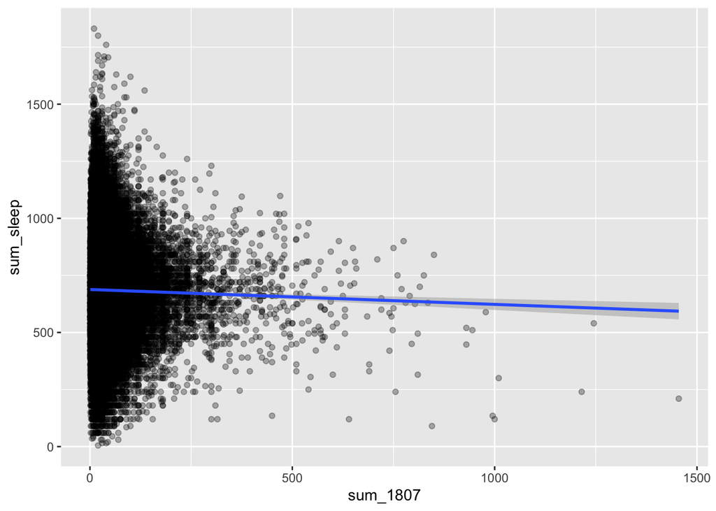

```r
reg_1807 %>% ggplot(aes(x= sum_1807, y= sum_sleep)) +
  geom_point(alpha = 0.3) +
  geom_smooth(method = "lm")
```

There is a slight negative relationship between the variables, so we will make a linear model.

```r
travel_1807_mod <- lm(sum_sleep~sum_1807, data = reg_1807)
summary(travel_1807_mod)
```

```
##
## Call:
## lm(formula = sum_sleep ~ sum_1807, data = reg_1807)
##
## Residuals:
##     Min      1Q  Median      3Q     Max
## -681.92 -113.66   -2.25  104.71 1143.43
##
## Coefficients:
##              Estimate Std. Error t value Pr(>|t|)
## (Intercept) 688.22382    0.76160 903.661  < 2e-16 ***
## sum_1807     -0.06521    0.01295  -5.037 4.73e-07 ***
## ---
## Signif. codes:  0 '***' 0.001 '**' 0.01 '*' 0.05 '.' 0.1 ' ' 1
##
## Residual standard error: 176.2 on 89421 degrees of freedom
##   (82 observations deleted due to missingness)
## Multiple R-squared:  0.0002837,  Adjusted R-squared:  0.0002725
## F-statistic: 25.37 on 1 and 89421 DF,  p-value: 4.733e-07
```

```r
confint(travel_1807_mod, "sum_1807", data = reg_1807, level = 0.99 )
```

```
##               0.5 %      99.5 %
## sum_1807 -0.0985558 -0.03186303
```

We are 99% confident that the coefficient for 1807 (consumer purchases) is between -0.0985558 and -0.03186303. The 99% confidence interval does not contain 0, so we are 99% sure that there is a small negative effect.

Let’s look at our next variable traveling for work (1805).

```r
reg_1805 <- left_join(atus_1805, atus_sleep, by = "TUCASEID")
head(reg_1805)
```

```
## # A tibble: 6 × 3
##   TUCASEID       sum_1805 sum_sleep
##   <I<chr>>          <dbl>     <dbl>
## 1 20030100014165       15       445
## 2 20030100014427       50       505
## 3 20030100014758        4       180
## 4 20030100014928       59       925
## 5 20030100015322        3       936
## 6 20030100015490       75       840
```

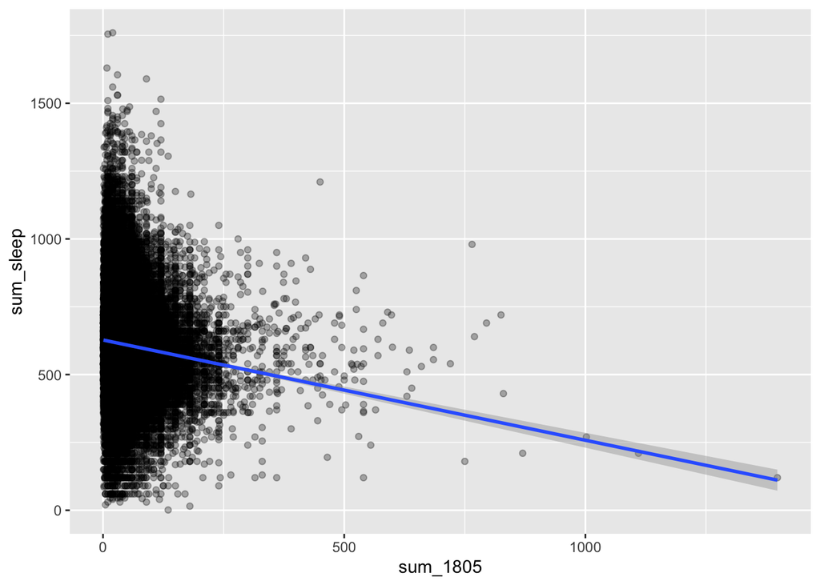

```r
reg_1805 %>% ggplot(aes(x= sum_1805, y= sum_sleep)) +
  geom_point(alpha = 0.3) +
  geom_smooth(method = "lm")
```

It looks like there is a negative correlation, but it seems to be caused by high outliers on the x-axis, so we will show a scatter plot that eliminates these points from view.

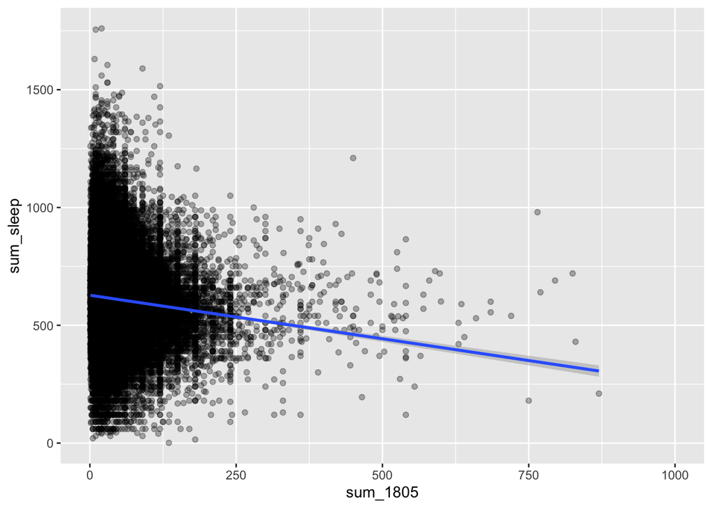

```r
reg_1805 %>% ggplot(aes(x= sum_1805, y= sum_sleep)) +
  geom_point(alpha = 0.3) +
  scale_x_continuous(limits = c(0, 1000)) +
  geom_smooth(method = "lm")
```

Without the very high outliers we can still see a negative correlation.

Regression of Time Traveling for work (1805) on Time Sleeping

```r
travel_1805_mod <- lm(sum_sleep~sum_1805, data = reg_1805)
summary(travel_1805_mod)
```

```
##
## Call:
## lm(formula = sum_sleep ~ sum_1805, data = reg_1805)
##
## Residuals:
##     Min      1Q  Median      3Q     Max
## -605.68 -102.75   -9.57   92.25 1139.86
##
## Coefficients:
##              Estimate Std. Error t value Pr(>|t|)
## (Intercept) 627.52940    0.91193  688.13   <2e-16 ***
## sum_1805     -0.36953    0.01462  -25.28   <2e-16 ***
## ---
## Signif. codes:  0 '***' 0.001 '**' 0.01 '*' 0.05 '.' 0.1 ' ' 1
##
## Residual standard error: 163.3 on 63587 degrees of freedom
##   (74 observations deleted due to missingness)
## Multiple R-squared:  0.009949,   Adjusted R-squared:  0.009933
## F-statistic:   639 on 1 and 63587 DF,  p-value: < 2.2e-16
```

```r
confint(travel_1805_mod, "sum_1805", data = reg_1805, level = 0.99 )
```

```
##               0.5 %     99.5 %
## sum_1805 -0.4071852 -0.3318718
```

We are 99% confident that the coefficient for 1805 (work) is between -0.4071852 and -0.3318718. Therefore there is a negative relationship because the confidence interval does not contain the value 0.

Now we will look at travel time for relaxing and leisure (1812)

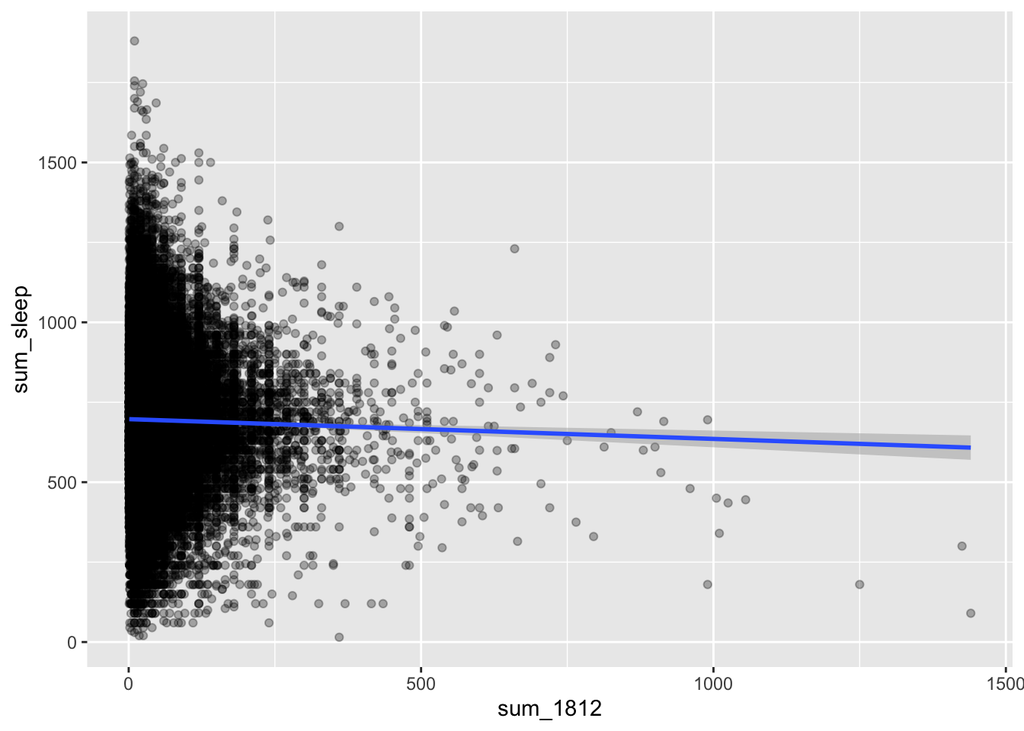

```r
reg_1812 <- left_join(atus_1812, atus_sleep, by = "TUCASEID")

reg_1812 %>% ggplot(aes(x= sum_1812, y= sum_sleep)) +
  geom_point(alpha = 0.3) +
  geom_smooth(method = "lm")
```

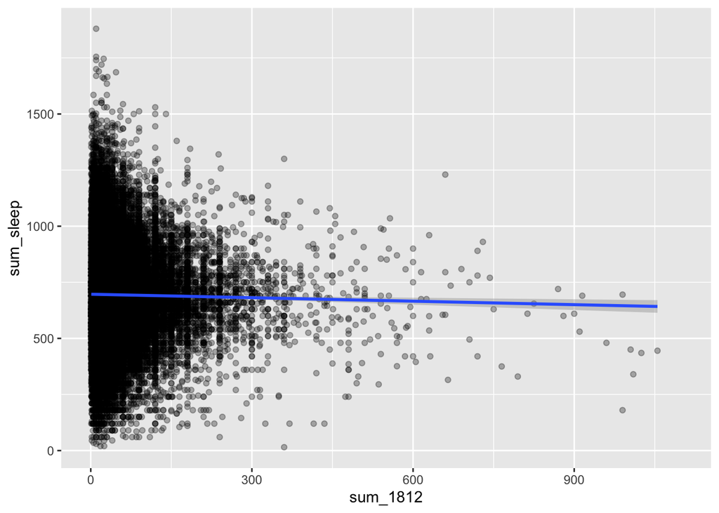

```r
reg_1812 %>% ggplot(aes(x= sum_1812, y= sum_sleep)) +
  geom_point(alpha = 0.3) +
  geom_smooth(method = "lm") +
  scale_x_continuous( limits = c(0, 1100))
```

Now we will run a model with both 1805 (work) and 1807 (consumer purchases)

```r
travel_full_reg<- reg_1805 %>% left_join(reg_1807)
na.omit(travel_full_reg)
```

```
## # A tibble: 22,159 × 4
##    TUCASEID       sum_1805 sum_sleep sum_1807
##    <I<chr>>          <dbl>     <dbl>    <dbl>
##  1 20030100014758        4       180       30
##  2 20030100015322        3       936       10
##  3 20030101030074       40       602       23
##  4 20030101030093        9       623        5
##  5 20030101030157       45       665       70
##  6 20030101030600       80       635       17
##  7 20030101030611       15       690       95
##  8 20030101030638       55       560       10
##  9 20030101030642       90       750       30
## 10 20030101031047       24       380       40
## # … with 22,149 more rows
```

```r
travel_full_mod <- lm(sum_sleep ~ sum_1805 + sum_1807, data=travel_full_reg)
summary(travel_full_mod)
```

```
##
## Call:
## lm(formula = sum_sleep ~ sum_1805 + sum_1807, data = travel_full_reg)
##
## Residuals:
##     Min      1Q  Median      3Q     Max
## -561.64  -99.49   -6.75   92.27 1020.30
##
## Coefficients:
##              Estimate Std. Error t value Pr(>|t|)
## (Intercept) 631.22645    1.74917 360.872  < 2e-16 ***
## sum_1805     -0.43743    0.02890 -15.136  < 2e-16 ***
## sum_1807     -0.26068    0.03409  -7.647 2.13e-14 ***
## ---
## Signif. codes:  0 '***' 0.001 '**' 0.01 '*' 0.05 '.' 0.1 ' ' 1
##
## Residual standard error: 157.5 on 22156 degrees of freedom
##   (41504 observations deleted due to missingness)
## Multiple R-squared:  0.01358,    Adjusted R-squared:  0.01349
## F-statistic: 152.5 on 2 and 22156 DF,  p-value: < 2.2e-16
```

```r
confint(travel_full_mod, "sum_1805", data = travel_full_reg, level = 0.99 )
```

```
##               0.5 %     99.5 %
## sum_1805 -0.5118716 -0.3629791
```

```r
confint(travel_full_mod, "sum_1807", data = travel_full_reg, level = 0.99 )
```

```
##               0.5 %    99.5 %
## sum_1807 -0.3484959 -0.172871
```

Both coefficients have very low p-values and are significant. We are 99% confident that the 1805 (work) coefficient is between -0.5118716 and -0.3629791 and that the 1807 (consumer purchases) coefficient is between -0.3484959 and -0.172871. Therefore, we are 99% confident that both variables have a negative effect on sleep time.

#### Part One Data Sets

1. Marisa Manno - Both Republicans And Democrats Have an Age Problem (congress-terms.csv)
2. Georgia Wright - How Boomers Get High (drug-use-by-age.csv)
3. Elizabeth Chin - Dear Mona, Which State Has The Worst Drivers? (bad_drivers from the fivethirtyeight library)